# FINAL PROJECT - DRUG CONSUMPTION ANALYSIS

### DIA 5

### Cyprien NICOLAY - Timothé VITAL - Anna ZENOU

# 0_Importing libraries and loading data

```python
import pandas as pd
import numpy as np
import matplotlib.pyplot as plt
import seaborn as sns
%matplotlib inline

from plotly.offline import download_plotlyjs, init_notebook_mode, plot, iplot
import plotly.offline as py
from plotly.graph_objs import Scatter, Layout
py.init_notebook_mode(connected=True)
import plotly.graph_objs as go
import plotly.figure_factory as ff

from sklearn import preprocessing
from sklearn.model_selection import GridSearchCV, train_test_split
from sklearn.preprocessing import StandardScaler
from sklearn.metrics import accuracy_score,f1_score
from sklearn import metrics
from sklearn.linear_model import LogisticRegression
from sklearn.model_selection import cross_val_score
from sklearn.preprocessing import LabelEncoder
```

#### Nommer explicitement les colonnes :

```python
#names = ['ID', 'Age', 'Genre', 'Education', 'Pays', 'Ethnicité', 'Neuroticisme', 'Extraversion', 'Ouverture', 'Agréabilité', 'Sérieux', 'Impulsivité', 'Recherche_de_sensation', 'Alcool', 'Amphetamine', 'Amyl_nitrite', 'Benzodiazepine', 'Caffeine', 'Cannabis', 'Chocolat', 'Cocaine', 'Crack', 'Ecstasy', 'Heroin', 'Ketamine', 'Drogues_légales', 'LSD', 'Methadone', 'Champignon', 'Nicotine', 'Semeron', 'Abus']
col_démographie=['ID', 'Age', 'Genre', 'Education', 'Pays', 'Ethnicité']
col_personnalité=['Neuroticisme', 'Extraversion', "Ouverture à l'expérience", 'Agréabilité', 'Sérieux', 'Impulsivité', 'Recherche de sensation']
col_drogue=['Alcool', 'Amphetamine', 'Amyl nitrite', 'Benzodiazepine', 'Caffeine', 'Cannabis', 'Chocolat', 'Cocaine', 'Crack', 'Ecstasy', 'Heroin', 'Ketamine', 'Substance psychoactive', 'LSD', 'Methadone', 'Champignon hallucinogène', 'Nicotine', 'Semeron', 'Substance Volatile']
#La Séparation entre drogues légales et illégales pourrait être utile plus tard
col_drogue_légale=['Alcool', 'Caffeine', 'Chocolat', 'Nicotine']
col_drogue_illégale=['Amphetamine', 'Amyl nitrite', 'Benzodiazepine', 'Cannabis', 'Cocaine', 'Crack', 'Ecstasy', 'Heroin', 'Ketamine', 'Substance psychoactive', 'LSD', 'Methadone', 'Champignon hallucinogène', 'Semeron','Substance Volatile']
colonnes=col_démographie+col_personnalité+col_drogue
```

```python
data = pd.read_csv(r'C:\Users\annaz\Desktop\A4\PYTHON FOR DATA ANALYSIS\Final Project\drug_consumption.data', names = colonnes)
pd.set_option('display.max_columns', 50)
#data.set_index('ID', inplace = True)
data
```

|  | ID | Age | Genre | Education | Pays | Ethnicité | Neuroticisme | Extraversion | Ouverture à l'expérience | Agréabilité | Sérieux | Impulsivité | Recherche de sensation | Alcool | Amphetamine | Amyl nitrite | Benzodiazepine | Caffeine | Cannabis | Chocolat | Cocaine | Crack | Ecstasy | Heroin | Ketamine | Substance psychoactive | LSD | Methadone | Champignon hallucinogène | … |
| --- | --- | --- | --- | --- | --- | --- | --- | --- | --- | --- | --- | --- | --- | --- | --- | --- | --- | --- | --- | --- | --- | --- | --- | --- | --- | --- | --- | --- | --- | --- |
| 0 | 1 | 0.49788 | 0.48246 | -0.05921 | 0.96082 | 0.12600 | 0.31287 | -0.57545 | -0.58331 | -0.91699 | -0.00665 | -0.21712 | -1.18084 | CL5 | CL2 | CL0 | CL2 | CL6 | CL0 | CL5 | CL0 | CL0 | CL0 | CL0 | CL0 | CL0 | CL0 | CL0 | CL0 | … |
| 1 | 2 | -0.07854 | -0.48246 | 1.98437 | 0.96082 | -0.31685 | -0.67825 | 1.93886 | 1.43533 | 0.76096 | -0.14277 | -0.71126 | -0.21575 | CL5 | CL2 | CL2 | CL0 | CL6 | CL4 | CL6 | CL3 | CL0 | CL4 | CL0 | CL2 | CL0 | CL2 | CL3 | CL0 | … |
| 2 | 3 | 0.49788 | -0.48246 | -0.05921 | 0.96082 | -0.31685 | -0.46725 | 0.80523 | -0.84732 | -1.62090 | -1.01450 | -1.37983 | 0.40148 | CL6 | CL0 | CL0 | CL0 | CL6 | CL3 | CL4 | CL0 | CL0 | CL0 | CL0 | CL0 | CL0 | CL0 | CL0 | CL1 | … |
| 3 | 4 | -0.95197 | 0.48246 | 1.16365 | 0.96082 | -0.31685 | -0.14882 | -0.80615 | -0.01928 | 0.59042 | 0.58489 | -1.37983 | -1.18084 | CL4 | CL0 | CL0 | CL3 | CL5 | CL2 | CL4 | CL2 | CL0 | CL0 | CL0 | CL2 | CL0 | CL0 | CL0 | CL0 | … |
| 4 | 5 | 0.49788 | 0.48246 | 1.98437 | 0.96082 | -0.31685 | 0.73545 | -1.63340 | -0.45174 | -0.30172 | 1.30612 | -0.21712 | -0.21575 | CL4 | CL1 | CL1 | CL0 | CL6 | CL3 | CL6 | CL0 | CL0 | CL1 | CL0 | CL0 | CL1 | CL0 | CL0 | CL2 | … |
| ... | ... | ... | ... | ... | ... | ... | ... | ... | ... | ... | ... | ... | ... | ... | ... | ... | ... | ... | ... | ... | ... | ... | ... | ... | ... | ... | ... | ... | ... | … |
| 1880 | 1884 | -0.95197 | 0.48246 | -0.61113 | -0.57009 | -0.31685 | -1.19430 | 1.74091 | 1.88511 | 0.76096 | -1.13788 | 0.88113 | 1.92173 | CL5 | CL0 | CL0 | CL0 | CL4 | CL5 | CL4 | CL0 | CL0 | CL0 | CL0 | CL0 | CL3 | CL3 | CL0 | CL0 | … |
| 1881 | 1885 | -0.95197 | -0.48246 | -0.61113 | -0.57009 | -0.31685 | -0.24649 | 1.74091 | 0.58331 | 0.76096 | -1.51840 | 0.88113 | 0.76540 | CL5 | CL0 | CL0 | CL0 | CL5 | CL3 | CL4 | CL0 | CL0 | CL2 | CL0 | CL0 | CL3 | CL5 | CL4 | CL4 | … |
| 1882 | 1886 | -0.07854 | 0.48246 | 0.45468 | -0.57009 | -0.31685 | 1.13281 | -1.37639 | -1.27553 | -1.77200 | -1.38502 | 0.52975 | -0.52593 | CL4 | CL6 | CL5 | CL5 | CL6 | CL6 | CL6 | CL4 | CL0 | CL4 | CL0 | CL2 | CL0 | CL2 | CL0 | CL2 | … |
| 1883 | 1887 | -0.95197 | 0.48246 | -0.61113 | -0.57009 | -0.31685 | 0.91093 | -1.92173 | 0.29338 | -1.62090 | -2.57309 | 1.29221 | 1.22470 | CL5 | CL0 | CL0 | CL0 | CL6 | CL6 | CL5 | CL0 | CL0 | CL3 | CL0 | CL0 | CL3 | CL3 | CL0 | CL3 | … |
| 1884 | 1888 | -0.95197 | -0.48246 | -0.61113 | 0.21128 | -0.31685 | -0.46725 | 2.12700 | 1.65653 | 1.11406 | 0.41594 | 0.88113 | 1.22470 | CL4 | CL3 | CL0 | CL3 | CL6 | CL3 | CL6 | CL3 | CL0 | CL3 | CL0 | CL0 | CL3 | CL3 | CL0 | CL3 | … |

1885 rows × 32 columns

```python
df = data.copy()
```

# 1_Data Pre-processing

### Explication et modification des colonnes

Les données numériques sont déjà normalisées.

Le dataset sur la consommation de drogues (quantifiée) est un dataset multi-label du UCI machine learning repository.

Le dataset contient des réponses pour 1885 répondants.

Pour résumer, il contient :

- une colonne ID
- 5 colonnes démographiques (caractéristiques)
- 7 traits de personnalité (caractéristiques)
- 18 drogues avec leur fréquence d'utilisation (cible)
- une fausse drogue appelée Semeron pour vérifier la fiabilité des réponses.

- CL0 : Jamais utilisée
- CL1 : Utilisée il y a plus d'une décennie
- CL2 : Utilisée au cours de la dernière décennie
- CL3 : Utilisée au cours de la dernière année
- CL4 : Utilisée au cours du dernier mois
- CL5 : Utilisée au cours de la dernière semaine
- CL6 : Utilisée au cours du dernier jour

Toutes les variables qualitatives ont été transformées en valeurs réelles (sauf les variables cibles).

### Cleaning Data

```python
data.shape
```

```
(1885, 32)
```

#### Check for missing values

```python
data.isnull().values.any()
```

```
False
```

Il n'y a pas de donnée manquante.

#### Overclaimers

Semeron est une drogue fictive qui a été introduite pour identifier les revandications excessives. Ces personnes seront exclues du dataset afin d'éviter des prédictions et des analyses inexactes, car leurs autres réponses pourraient également être erronées.

```python
overclaimers = data[data['Semeron'] != 'CL0']
overclaimers
# There are 8 people who claimed they used Semeron, the fictitious drug.
```

|  | ID | Age | Genre | Education | Pays | Ethnicité | Neuroticisme | Extraversion | Ouverture à l'expérience | Agréabilité | Sérieux | Impulsivité | Recherche de sensation | Alcool | Amphetamine | Amyl nitrite | Benzodiazepine | Caffeine | Cannabis | Chocolat | Cocaine | Crack | Ecstasy | Heroin | Ketamine | Substance psychoactive | LSD | Methadone | Champignon hallucinogène | … |
| --- | --- | --- | --- | --- | --- | --- | --- | --- | --- | --- | --- | --- | --- | --- | --- | --- | --- | --- | --- | --- | --- | --- | --- | --- | --- | --- | --- | --- | --- | --- |
| 727 | 730 | -0.07854 | 0.48246 | -1.73790 | -0.09765 | -0.31685 | -0.58016 | 0.32197 | 0.14143 | -0.60633 | 0.12331 | 1.29221 | 0.76540 | CL6 | CL2 | CL2 | CL2 | CL6 | CL6 | CL5 | CL2 | CL2 | CL2 | CL2 | CL2 | CL0 | CL4 | CL2 | CL6 | … |
| 817 | 821 | -0.95197 | -0.48246 | -0.61113 | -0.09765 | -0.50212 | -0.67825 | 1.74091 | 0.72330 | 0.13136 | 0.41594 | 0.88113 | 1.92173 | CL3 | CL0 | CL0 | CL0 | CL6 | CL4 | CL5 | CL0 | CL0 | CL3 | CL0 | CL0 | CL0 | CL5 | CL0 | CL5 | … |
| 1516 | 1520 | -0.95197 | -0.48246 | -0.61113 | -0.57009 | -0.31685 | -0.24649 | -0.80615 | -1.27553 | -1.34289 | -1.92173 | -0.71126 | 0.07987 | CL0 | CL2 | CL3 | CL2 | CL3 | CL4 | CL1 | CL3 | CL2 | CL1 | CL2 | CL1 | CL2 | CL1 | CL2 | CL4 | … |
| 1533 | 1537 | -0.95197 | 0.48246 | -0.61113 | -0.57009 | 0.11440 | -0.46725 | 0.80523 | 0.29338 | 2.03972 | 1.81175 | -1.37983 | -0.21575 | CL5 | CL6 | CL0 | CL4 | CL6 | CL3 | CL6 | CL4 | CL0 | CL4 | CL0 | CL4 | CL3 | CL2 | CL0 | CL3 | … |
| 1698 | 1702 | 0.49788 | 0.48246 | 0.45468 | -0.57009 | -0.31685 | 1.98437 | -0.80615 | 2.15324 | 0.76096 | -0.00665 | 1.29221 | 1.92173 | CL6 | CL0 | CL0 | CL3 | CL5 | CL6 | CL4 | CL2 | CL0 | CL2 | CL0 | CL2 | CL2 | CL2 | CL0 | CL2 | … |
| 1769 | 1773 | -0.95197 | -0.48246 | -1.22751 | -0.57009 | -0.22166 | -0.34799 | 1.28610 | 1.06238 | -0.01729 | -0.52745 | 0.52975 | 1.22470 | CL4 | CL3 | CL0 | CL3 | CL6 | CL6 | CL6 | CL0 | CL0 | CL3 | CL0 | CL4 | CL3 | CL6 | CL3 | CL3 | … |
| 1806 | 1810 | -0.95197 | 0.48246 | -1.43719 | -0.57009 | -0.31685 | 1.23461 | 1.11406 | 1.06238 | -1.47955 | 0.12331 | 0.88113 | 1.92173 | CL4 | CL3 | CL0 | CL2 | CL6 | CL6 | CL3 | CL5 | CL2 | CL4 | CL2 | CL1 | CL4 | CL1 | CL0 | CL1 | … |
| 1823 | 1827 | -0.95197 | 0.48246 | 0.45468 | -0.57009 | -0.31685 | 0.22393 | -0.30033 | 0.88309 | 1.28610 | -0.00665 | 0.88113 | 0.07987 | CL4 | CL0 | CL0 | CL2 | CL5 | CL6 | CL5 | CL2 | CL0 | CL0 | CL0 | CL0 | CL2 | CL3 | CL0 | CL3 | … |

```python
data = data[data['Semeron'] == 'CL0']
# Removing it from drug lists
col_drogue.remove('Semeron')
col_drogue_illégale.remove('Semeron')
#Dropping the column from the dataset
data.drop(['Semeron'], axis=1,inplace = True)

data.shape
```

```
(1877, 31)
```

#### Colonnes pays et ethnicité

```python
data.drop(['Pays'], axis=1,inplace = True)
col_démographie.remove('Pays')
data.drop(['Ethnicité'], axis=1,inplace = True)
col_démographie.remove('Ethnicité')
data.columns
```

```
Index(['ID', 'Age', 'Genre', 'Education', 'Neuroticisme', 'Extraversion',
       'Ouverture à l'expérience', 'Agréabilité', 'Sérieux', 'Impulsivité',
       'Recherche de sensation', 'Alcool', 'Amphetamine', 'Amyl nitrite',
       'Benzodiazepine', 'Caffeine', 'Cannabis', 'Chocolat', 'Cocaine',
       'Crack', 'Ecstasy', 'Heroin', 'Ketamine', 'Substance psychoactive',
       'LSD', 'Methadone', 'Champignon hallucinogène', 'Nicotine',
       'Substance Volatile'],
      dtype='object')
```

#### Colonne genre

```python
def genre(x):
    if (x == 0.48246 ):
        x = 0
    elif (x == -0.48246 ):
        x = 1
    return x

data['Genre'] = data['Genre'].map(genre)
data.head()
```

|  | ID | Age | Genre | Education | Neuroticisme | Extraversion | Ouverture à l'expérience | Agréabilité | Sérieux | Impulsivité | Recherche de sensation | Alcool | Amphetamine | Amyl nitrite | Benzodiazepine | Caffeine | Cannabis | Chocolat | Cocaine | Crack | Ecstasy | Heroin | Ketamine | Substance psychoactive | LSD | Methadone | Champignon hallucinogène | Nicotine | Substance Volatile |
| --- | --- | --- | --- | --- | --- | --- | --- | --- | --- | --- | --- | --- | --- | --- | --- | --- | --- | --- | --- | --- | --- | --- | --- | --- | --- | --- | --- | --- | --- |
| 0 | 1 | 0.49788 | 0 | -0.05921 | 0.31287 | -0.57545 | -0.58331 | -0.91699 | -0.00665 | -0.21712 | -1.18084 | CL5 | CL2 | CL0 | CL2 | CL6 | CL0 | CL5 | CL0 | CL0 | CL0 | CL0 | CL0 | CL0 | CL0 | CL0 | CL0 | CL2 | CL0 |
| 1 | 2 | -0.07854 | 1 | 1.98437 | -0.67825 | 1.93886 | 1.43533 | 0.76096 | -0.14277 | -0.71126 | -0.21575 | CL5 | CL2 | CL2 | CL0 | CL6 | CL4 | CL6 | CL3 | CL0 | CL4 | CL0 | CL2 | CL0 | CL2 | CL3 | CL0 | CL4 | CL0 |
| 2 | 3 | 0.49788 | 1 | -0.05921 | -0.46725 | 0.80523 | -0.84732 | -1.62090 | -1.01450 | -1.37983 | 0.40148 | CL6 | CL0 | CL0 | CL0 | CL6 | CL3 | CL4 | CL0 | CL0 | CL0 | CL0 | CL0 | CL0 | CL0 | CL0 | CL1 | CL0 | CL0 |
| 3 | 4 | -0.95197 | 0 | 1.16365 | -0.14882 | -0.80615 | -0.01928 | 0.59042 | 0.58489 | -1.37983 | -1.18084 | CL4 | CL0 | CL0 | CL3 | CL5 | CL2 | CL4 | CL2 | CL0 | CL0 | CL0 | CL2 | CL0 | CL0 | CL0 | CL0 | CL2 | CL0 |
| 4 | 5 | 0.49788 | 0 | 1.98437 | 0.73545 | -1.63340 | -0.45174 | -0.30172 | 1.30612 | -0.21712 | -0.21575 | CL4 | CL1 | CL1 | CL0 | CL6 | CL3 | CL6 | CL0 | CL0 | CL1 | CL0 | CL0 | CL1 | CL0 | CL0 | CL2 | CL2 | CL0 |

#### Problèmes de classification

A partir de ça on peut identifier deux problémes de classification : quelles types de personnes sont sujettes à avoir déjà testé telle drogue (CL0 vs autres), et quelles types de peresonnes sont sujettes à consommer telle drogue régulièrement (CL5+CL6 vs autres).

Nous allons ainsi attribuer la valeur 1 aux individus qui consomme régulièrement une drogue (CL5 et CL6) et la valeur 0 aux autres (CL0 à 4).

```python
def regulier(f):
    if ((f=='CL6') or (f=='CL5')):
        f = 1
    elif ((f=='CL0') or (f=='CL1') or (f=='CL2') or (f=='CL3') or (f=='CL4')):
        f = 0
    return f
```

```python
data_regulier=data.copy()
for col in col_drogue:
    data_regulier[col]=data_regulier[col].map(regulier)
data_regulier.head()
```

|  | ID | Age | Genre | Education | Neuroticisme | Extraversion | Ouverture à l'expérience | Agréabilité | Sérieux | Impulsivité | Recherche de sensation | Alcool | Amphetamine | Amyl nitrite | Benzodiazepine | Caffeine | Cannabis | Chocolat | Cocaine | Crack | Ecstasy | Heroin | Ketamine | Substance psychoactive | LSD | Methadone | Champignon hallucinogène | Nicotine | Substance Volatile |
| --- | --- | --- | --- | --- | --- | --- | --- | --- | --- | --- | --- | --- | --- | --- | --- | --- | --- | --- | --- | --- | --- | --- | --- | --- | --- | --- | --- | --- | --- |
| 0 | 1 | 0.49788 | 0 | -0.05921 | 0.31287 | -0.57545 | -0.58331 | -0.91699 | -0.00665 | -0.21712 | -1.18084 | 1 | 0 | 0 | 0 | 1 | 0 | 1 | 0 | 0 | 0 | 0 | 0 | 0 | 0 | 0 | 0 | 0 | 0 |
| 1 | 2 | -0.07854 | 1 | 1.98437 | -0.67825 | 1.93886 | 1.43533 | 0.76096 | -0.14277 | -0.71126 | -0.21575 | 1 | 0 | 0 | 0 | 1 | 0 | 1 | 0 | 0 | 0 | 0 | 0 | 0 | 0 | 0 | 0 | 0 | 0 |
| 2 | 3 | 0.49788 | 1 | -0.05921 | -0.46725 | 0.80523 | -0.84732 | -1.62090 | -1.01450 | -1.37983 | 0.40148 | 1 | 0 | 0 | 0 | 1 | 0 | 0 | 0 | 0 | 0 | 0 | 0 | 0 | 0 | 0 | 0 | 0 | 0 |
| 3 | 4 | -0.95197 | 0 | 1.16365 | -0.14882 | -0.80615 | -0.01928 | 0.59042 | 0.58489 | -1.37983 | -1.18084 | 0 | 0 | 0 | 0 | 1 | 0 | 0 | 0 | 0 | 0 | 0 | 0 | 0 | 0 | 0 | 0 | 0 | 0 |
| 4 | 5 | 0.49788 | 0 | 1.98437 | 0.73545 | -1.63340 | -0.45174 | -0.30172 | 1.30612 | -0.21712 | -0.21575 | 0 | 0 | 0 | 0 | 1 | 0 | 1 | 0 | 0 | 0 | 0 | 0 | 0 | 0 | 0 | 0 | 0 | 0 |

#### Encode drug columns into numeric data

```python
for column in col_drogue:
    le = LabelEncoder()
    data[column] = le.fit_transform(data[column])
```

```python
for column in col_drogue:
    le = LabelEncoder()
    df[column] = le.fit_transform(df[column])

for column in col_démographie:
    le = LabelEncoder()
    df[column] = le.fit_transform(df[column])

for column in col_personnalité:
    le = LabelEncoder()
    df[column] = le.fit_transform(df[column])
```

```python
df
```

|  | ID | Age | Genre | Education | Pays | Ethnicité | Neuroticisme | Extraversion | Ouverture à l'expérience | Agréabilité | Sérieux | Impulsivité | Recherche de sensation | Alcool | Amphetamine | Amyl nitrite | Benzodiazepine | Caffeine | Cannabis | Chocolat | Cocaine | Crack | Ecstasy | Heroin | Ketamine | Substance psychoactive | LSD | Methadone | Champignon hallucinogène | … |
| --- | --- | --- | --- | --- | --- | --- | --- | --- | --- | --- | --- | --- | --- | --- | --- | --- | --- | --- | --- | --- | --- | --- | --- | --- | --- | --- | --- | --- | --- | --- |
| 0 | 0 | 2 | 1 | 5 | 0.96082 | 0.12600 | 27 | 19 | 16 | 17 | 24 | 3 | 2 | 5 | 2 | 0 | 2 | 6 | 0 | 5 | 0 | 0 | 0 | 0 | 0 | 0 | 0 | 0 | 0 | … |
| 1 | 1 | 1 | 0 | 8 | 0.96082 | -0.31685 | 17 | 35 | 29 | 28 | 23 | 2 | 5 | 5 | 2 | 2 | 0 | 6 | 4 | 6 | 3 | 0 | 4 | 0 | 2 | 0 | 2 | 3 | 0 | … |
| 2 | 2 | 2 | 0 | 5 | 0.96082 | -0.31685 | 19 | 28 | 14 | 12 | 16 | 1 | 7 | 6 | 0 | 0 | 0 | 6 | 3 | 4 | 0 | 0 | 0 | 0 | 0 | 0 | 0 | 0 | 1 | … |
| 3 | 3 | 0 | 1 | 7 | 0.96082 | -0.31685 | 22 | 17 | 20 | 27 | 28 | 1 | 2 | 4 | 0 | 0 | 3 | 5 | 2 | 4 | 2 | 0 | 0 | 0 | 2 | 0 | 0 | 0 | 0 | … |
| 4 | 4 | 2 | 1 | 8 | 0.96082 | -0.31685 | 31 | 11 | 17 | 21 | 32 | 3 | 5 | 4 | 1 | 1 | 0 | 6 | 3 | 6 | 0 | 0 | 1 | 0 | 0 | 1 | 0 | 0 | 2 | … |
| ... | ... | ... | ... | ... | ... | ... | ... | ... | ... | ... | ... | ... | ... | ... | ... | ... | ... | ... | ... | ... | ... | ... | ... | ... | ... | ... | ... | ... | ... | … |
| 1880 | 1880 | 0 | 1 | 4 | -0.57009 | -0.31685 | 13 | 34 | 31 | 28 | 15 | 6 | 10 | 5 | 0 | 0 | 0 | 4 | 5 | 4 | 0 | 0 | 0 | 0 | 0 | 3 | 3 | 0 | 0 | … |
| 1881 | 1881 | 0 | 0 | 4 | -0.57009 | -0.31685 | 21 | 34 | 24 | 28 | 12 | 6 | 8 | 5 | 0 | 0 | 0 | 5 | 3 | 4 | 0 | 0 | 2 | 0 | 0 | 3 | 5 | 4 | 4 | … |
| 1882 | 1882 | 1 | 1 | 6 | -0.57009 | -0.31685 | 35 | 13 | 11 | 11 | 13 | 5 | 4 | 4 | 6 | 5 | 5 | 6 | 6 | 6 | 4 | 0 | 4 | 0 | 2 | 0 | 2 | 0 | 2 | … |
| 1883 | 1883 | 0 | 1 | 4 | -0.57009 | -0.31685 | 33 | 9 | 22 | 12 | 4 | 7 | 9 | 5 | 0 | 0 | 0 | 6 | 6 | 5 | 0 | 0 | 3 | 0 | 0 | 3 | 3 | 0 | 3 | … |
| 1884 | 1884 | 0 | 0 | 4 | 0.21128 | -0.31685 | 19 | 36 | 30 | 30 | 27 | 6 | 9 | 4 | 3 | 0 | 3 | 6 | 3 | 6 | 3 | 0 | 3 | 0 | 0 | 3 | 3 | 0 | 3 | … |

1885 rows × 32 columns

#### Colonnes Age et Education

Pour mieux comprendre la colonne age et éducation, au lieu de donner une valeur à chaque tranche d'âge ce qui pourrait influencer injustement les algorithmes de prédiction du fait qu'elles ne soient pas ordinales, on propose de faire une collone T/F pour chaque valeur possible (one-hot encoding).

```python
oh_data= pd.get_dummies(data_regulier, columns = ['Age', 'Education'])
oh_data.head()
```

|  | ID | Genre | Neuroticisme | Extraversion | Ouverture à l'expérience | Agréabilité | Sérieux | Impulsivité | Recherche de sensation | Alcool | Amphetamine | Amyl nitrite | Benzodiazepine | Caffeine | Cannabis | Chocolat | Cocaine | Crack | Ecstasy | Heroin | Ketamine | Substance psychoactive | LSD | Methadone | Champignon hallucinogène | Nicotine | Substance Volatile | Age_-0.95197 | Age_-0.07854 | … |
| --- | --- | --- | --- | --- | --- | --- | --- | --- | --- | --- | --- | --- | --- | --- | --- | --- | --- | --- | --- | --- | --- | --- | --- | --- | --- | --- | --- | --- | --- | --- |
| 0 | 1 | 0 | 0.31287 | -0.57545 | -0.58331 | -0.91699 | -0.00665 | -0.21712 | -1.18084 | 1 | 0 | 0 | 0 | 1 | 0 | 1 | 0 | 0 | 0 | 0 | 0 | 0 | 0 | 0 | 0 | 0 | 0 | 0 | 0 | … |
| 1 | 2 | 1 | -0.67825 | 1.93886 | 1.43533 | 0.76096 | -0.14277 | -0.71126 | -0.21575 | 1 | 0 | 0 | 0 | 1 | 0 | 1 | 0 | 0 | 0 | 0 | 0 | 0 | 0 | 0 | 0 | 0 | 0 | 0 | 1 | … |
| 2 | 3 | 1 | -0.46725 | 0.80523 | -0.84732 | -1.62090 | -1.01450 | -1.37983 | 0.40148 | 1 | 0 | 0 | 0 | 1 | 0 | 0 | 0 | 0 | 0 | 0 | 0 | 0 | 0 | 0 | 0 | 0 | 0 | 0 | 0 | … |
| 3 | 4 | 0 | -0.14882 | -0.80615 | -0.01928 | 0.59042 | 0.58489 | -1.37983 | -1.18084 | 0 | 0 | 0 | 0 | 1 | 0 | 0 | 0 | 0 | 0 | 0 | 0 | 0 | 0 | 0 | 0 | 0 | 0 | 1 | 0 | … |
| 4 | 5 | 0 | 0.73545 | -1.63340 | -0.45174 | -0.30172 | 1.30612 | -0.21712 | -0.21575 | 0 | 0 | 0 | 0 | 1 | 0 | 1 | 0 | 0 | 0 | 0 | 0 | 0 | 0 | 0 | 0 | 0 | 0 | 0 | 0 | … |

On peut au passage faire le tri : d'après les informations fournies sur les attributs : les 65+ ne représentent que 0.95%, pour ce qui est de l'éducation on peut regrouper les décrochage avant 16 ans et les décrochage à 16 ans qui représent 1.5% et 5%, et de même regrouper les décrochages à 17 et 18 ans.

```python
oh_data.drop(['Age_2.59171'], axis=1,inplace = True)

oh_data.rename(columns = {'Age_-0.95197':'Age: 18-24',
                          'Age_-0.07854':'Age: 25-34',
                          'Age_0.49788':'Age: 35-44',
                          'Age_1.09449':'Age: 45-54',
                          'Age_1.82213':'Age: 55-64',
                          'Education_-2.43591':'Décrochage avant 16 ans',
                          'Education_-1.7379':'Décrochage à 16 ans',
                          'Education_-1.43719':'Décrochage à 17 ans',
                          'Education_-1.22751':'Décrochage à 18 ans',
                          'Education_-0.61113':'Ecole supérieure ou Université',
                          'Education_-0.05921':'Certificat professionnel',
                          'Education_0.45468':'Diplômé universitaire',
                          'Education_1.16365':'Diplômé de master',
                          'Education_1.98437':'Diplômé de doctorat'
                         }, inplace = True)
oh_data.head()
```

|  | ID | Genre | Neuroticisme | Extraversion | Ouverture à l'expérience | Agréabilité | Sérieux | Impulsivité | Recherche de sensation | Alcool | Amphetamine | Amyl nitrite | Benzodiazepine | Caffeine | Cannabis | Chocolat | Cocaine | Crack | Ecstasy | Heroin | Ketamine | Substance psychoactive | LSD | Methadone | Champignon hallucinogène | Nicotine | Substance Volatile | Age: 18-24 | Age: 25-34 | … |
| --- | --- | --- | --- | --- | --- | --- | --- | --- | --- | --- | --- | --- | --- | --- | --- | --- | --- | --- | --- | --- | --- | --- | --- | --- | --- | --- | --- | --- | --- | --- |
| 0 | 1 | 0 | 0.31287 | -0.57545 | -0.58331 | -0.91699 | -0.00665 | -0.21712 | -1.18084 | 1 | 0 | 0 | 0 | 1 | 0 | 1 | 0 | 0 | 0 | 0 | 0 | 0 | 0 | 0 | 0 | 0 | 0 | 0 | 0 | … |
| 1 | 2 | 1 | -0.67825 | 1.93886 | 1.43533 | 0.76096 | -0.14277 | -0.71126 | -0.21575 | 1 | 0 | 0 | 0 | 1 | 0 | 1 | 0 | 0 | 0 | 0 | 0 | 0 | 0 | 0 | 0 | 0 | 0 | 0 | 1 | … |
| 2 | 3 | 1 | -0.46725 | 0.80523 | -0.84732 | -1.62090 | -1.01450 | -1.37983 | 0.40148 | 1 | 0 | 0 | 0 | 1 | 0 | 0 | 0 | 0 | 0 | 0 | 0 | 0 | 0 | 0 | 0 | 0 | 0 | 0 | 0 | … |
| 3 | 4 | 0 | -0.14882 | -0.80615 | -0.01928 | 0.59042 | 0.58489 | -1.37983 | -1.18084 | 0 | 0 | 0 | 0 | 1 | 0 | 0 | 0 | 0 | 0 | 0 | 0 | 0 | 0 | 0 | 0 | 0 | 0 | 1 | 0 | … |
| 4 | 5 | 0 | 0.73545 | -1.63340 | -0.45174 | -0.30172 | 1.30612 | -0.21712 | -0.21575 | 0 | 0 | 0 | 0 | 1 | 0 | 1 | 0 | 0 | 0 | 0 | 0 | 0 | 0 | 0 | 0 | 0 | 0 | 0 | 0 | … |

# 2_Data Visualization

#### Description des caractéristiques démographiques et de personnalité

```python
data.describe()
```

|  | ID | Age | Genre | Education | Neuroticisme | Extraversion | Ouverture à l'expérience | Agréabilité | Sérieux | Impulsivité | Recherche de sensation | Alcool | Amphetamine | Amyl nitrite | Benzodiazepine | Caffeine | Cannabis | Chocolat | Cocaine | Crack | Ecstasy | Heroin | Ketamine | Substance psychoactive | LSD | Methadone | Champignon hallucinogène | Nicotine | Substance Volatile |
| --- | --- | --- | --- | --- | --- | --- | --- | --- | --- | --- | --- | --- | --- | --- | --- | --- | --- | --- | --- | --- | --- | --- | --- | --- | --- | --- | --- | --- | --- |
| count | 1877.000000 | 1877.000000 | 1877.000000 | 1877.000000 | 1877.000000 | 1877.000000 | 1877.000000 | 1877.000000 | 1877.000000 | 1877.000000 | 1877.000000 | 1877.000000 | 1877.000000 | 1877.000000 | 1877.000000 | 1877.000000 | 1877.000000 | 1877.000000 | 1877.000000 | 1877.000000 | 1877.000000 | 1877.000000 | 1877.000000 | 1877.000000 | 1877.000000 | 1877.000000 | 1877.000000 | 1877.000000 | 1877.000000 |
| mean | 943.079915 | 0.037577 | 0.500799 | -0.000984 | -0.000551 | -0.001951 | -0.003224 | -0.000657 | -0.000394 | 0.005293 | -0.007408 | 4.637720 | 1.337773 | 0.606819 | 1.461907 | 5.484283 | 2.980288 | 5.109750 | 1.156633 | 0.295685 | 1.309536 | 0.372403 | 0.564198 | 1.353223 | 1.053277 | 0.826319 | 1.177944 | 3.194992 | 0.429409 |
| std | 544.601919 | 0.878387 | 0.500133 | 0.949831 | 0.998442 | 0.997418 | 0.995691 | 0.996689 | 0.997657 | 0.954148 | 0.962074 | 1.328234 | 1.782384 | 1.064005 | 1.869193 | 1.115119 | 2.286778 | 1.085716 | 1.510791 | 0.835925 | 1.647373 | 1.034761 | 1.216341 | 1.790881 | 1.484582 | 1.648379 | 1.459212 | 2.415814 | 0.959160 |
| min | 1.000000 | -0.951970 | 0.000000 | -2.435910 | -3.464360 | -3.273930 | -3.273930 | -3.464360 | -3.464360 | -2.555240 | -2.078480 | 0.000000 | 0.000000 | 0.000000 | 0.000000 | 0.000000 | 0.000000 | 0.000000 | 0.000000 | 0.000000 | 0.000000 | 0.000000 | 0.000000 | 0.000000 | 0.000000 | 0.000000 | 0.000000 | 0.000000 | 0.000000 |
| 25% | 472.000000 | -0.951970 | 0.000000 | -0.611130 | -0.678250 | -0.695090 | -0.717270 | -0.606330 | -0.652530 | -0.711260 | -0.525930 | 4.000000 | 0.000000 | 0.000000 | 0.000000 | 5.000000 | 1.000000 | 5.000000 | 0.000000 | 0.000000 | 0.000000 | 0.000000 | 0.000000 | 0.000000 | 0.000000 | 0.000000 | 0.000000 | 1.000000 | 0.000000 |
| 50% | 944.000000 | -0.078540 | 1.000000 | -0.059210 | 0.042570 | 0.003320 | -0.019280 | -0.017290 | -0.006650 | -0.217120 | 0.079870 | 5.000000 | 0.000000 | 0.000000 | 0.000000 | 6.000000 | 3.000000 | 5.000000 | 0.000000 | 0.000000 | 0.000000 | 0.000000 | 0.000000 | 0.000000 | 0.000000 | 0.000000 | 0.000000 | 3.000000 | 0.000000 |
| 75% | 1413.000000 | 0.497880 | 1.000000 | 0.454680 | 0.629670 | 0.637790 | 0.723300 | 0.760960 | 0.584890 | 0.529750 | 0.765400 | 6.000000 | 2.000000 | 1.000000 | 3.000000 | 6.000000 | 5.000000 | 6.000000 | 2.000000 | 0.000000 | 3.000000 | 0.000000 | 0.000000 | 3.000000 | 2.000000 | 0.000000 | 2.000000 | 6.000000 | 0.000000 |
| max | 1888.000000 | 2.591710 | 1.000000 | 1.984370 | 3.273930 | 3.273930 | 2.901610 | 3.464360 | 3.464360 | 2.901610 | 1.921730 | 6.000000 | 6.000000 | 6.000000 | 6.000000 | 6.000000 | 6.000000 | 6.000000 | 6.000000 | 6.000000 | 6.000000 | 6.000000 | 6.000000 | 6.000000 | 6.000000 | 6.000000 | 6.000000 | 6.000000 | 6.000000 |

Pour que ces résultats soit plus lisibles et parlant, affichons-les sous forme de Box plots. On remarquera que les valeurs des colonnes des caractéristiques des individus sont centrées autour de 0. Les données ont donc été standardisées.

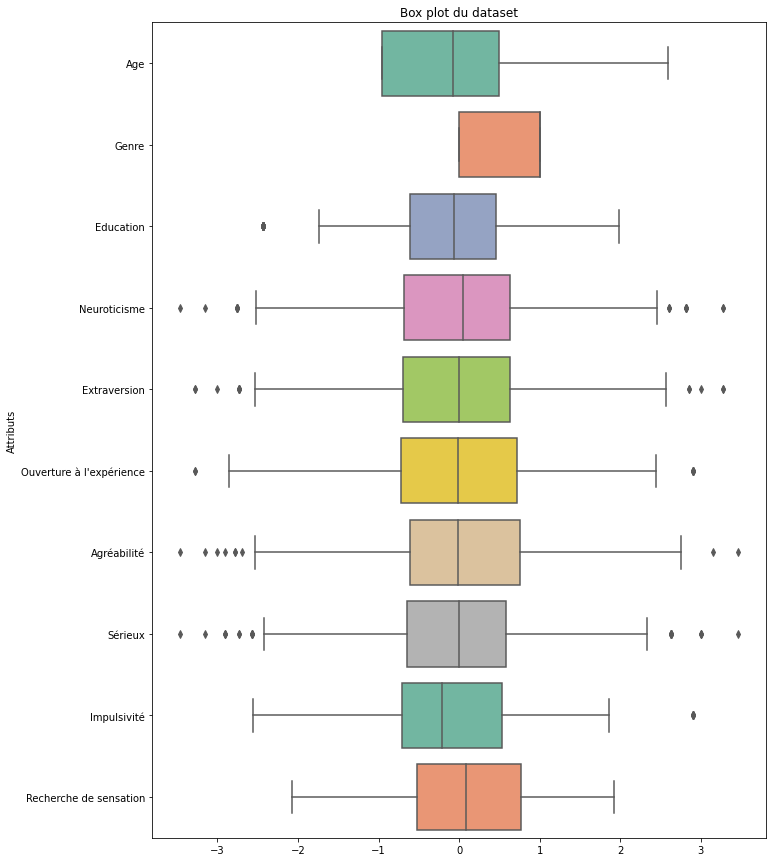

```python
fig, ax = plt.subplots(figsize=(11,15))
plt.ylabel("Attributs")
plt.title("Box plot du dataset")
ax = sns.boxplot(data = data[['Age', 'Genre', 'Education']+col_personnalité], orient="h", palette="Set2")
sns.reset_orig()
```

### Visualisation des proportions pour chaque caractéristique démographique et de personnalité

```python
def visu(data, col):
    plt.rc('font', size=10)
    colors = sns.color_palette('pastel')
    fig,axes = plt.subplots(1,2, figsize=(20,5))
    data[col].value_counts().sort_index().plot.pie(colors = colors,
                                             ax=axes[0],
                                             title=f'Pie Chart : {col}',
                                             autopct='%.2f%%',
                                             ylabel='')
    data[col].value_counts().sort_index().plot.bar(color = colors,
                                             ax=axes[1],
                                             title=f'Bar Chart : {col}',
                                             ylabel='')
    plt.show()
```

#### Caractéristiques démographiques

##### Rappel des différentes catégories :

###### Age :

- 0 : 18-24 ans
- 1 : 25-34 ans
- 2 : 35-44 ans
- 3 : 45-54 ans
- 4 : 55-64 ans
- 5 : 65+ ans

###### Education :

- 0 : Left school before 16 years
- 1 : Left school at 16 years
- 2 : Left school at 17 years
- 3 : Left school at 18 years
- 4 : Some college or university, no certificate or degree
- 5 : Professional certificate/ diploma
- 6 : University degree
- 7 : Masters degree
- 8 : Doctorate degree

###### Genre :

- 0 : homme
- 1 : femme

###### Ethnicité :

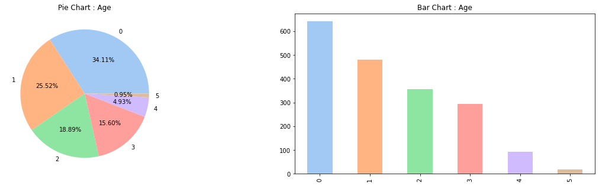

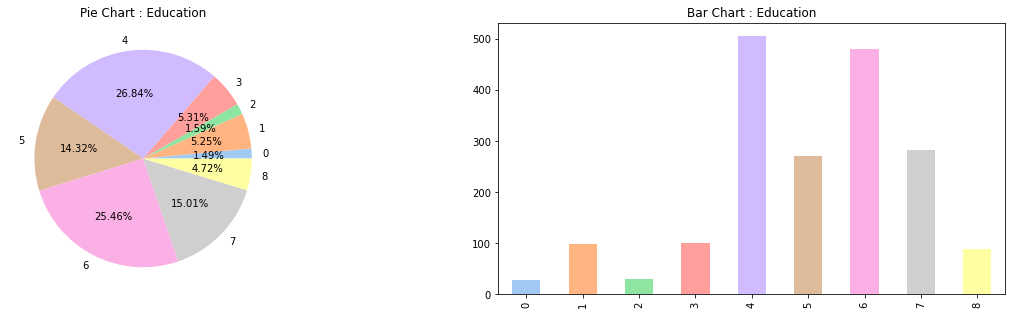

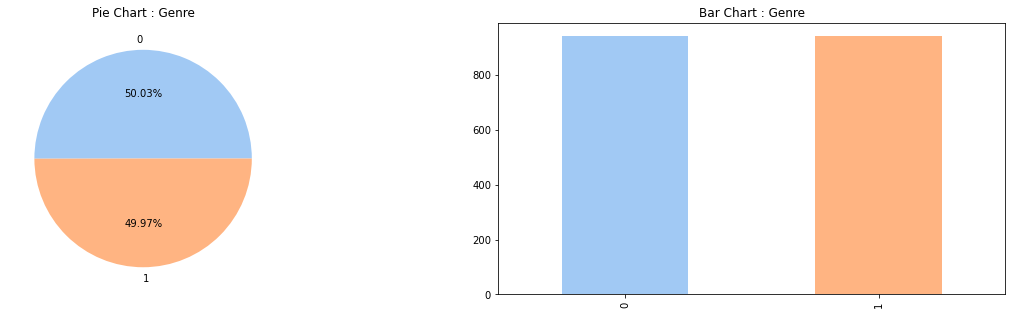

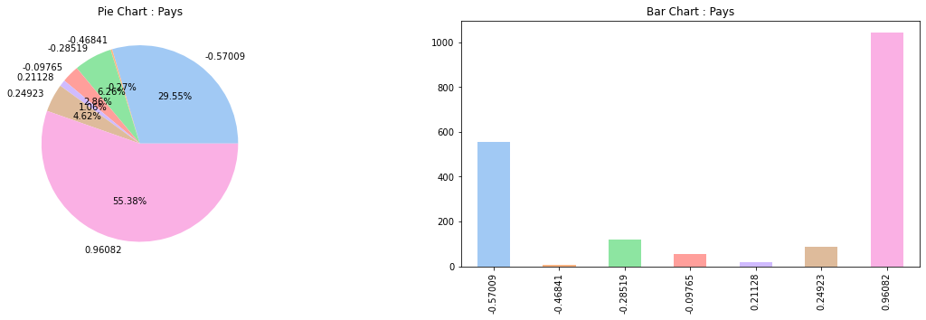

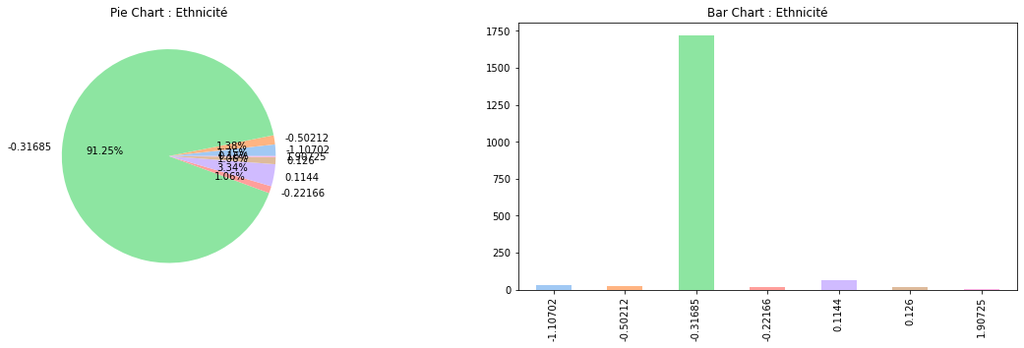

```python
visu(df, 'Age')
visu(df, 'Education')
visu(df, 'Genre')
visu(df, 'Pays')
visu(df, 'Ethnicité')
```

On utilisera donc le dataset sans ces les colonnes Pays et Ethnicité.

#### Caractéristiques de personnalité

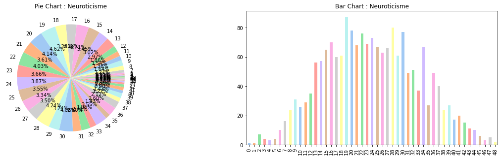

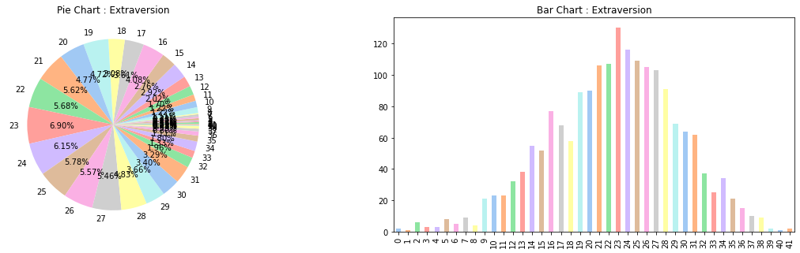

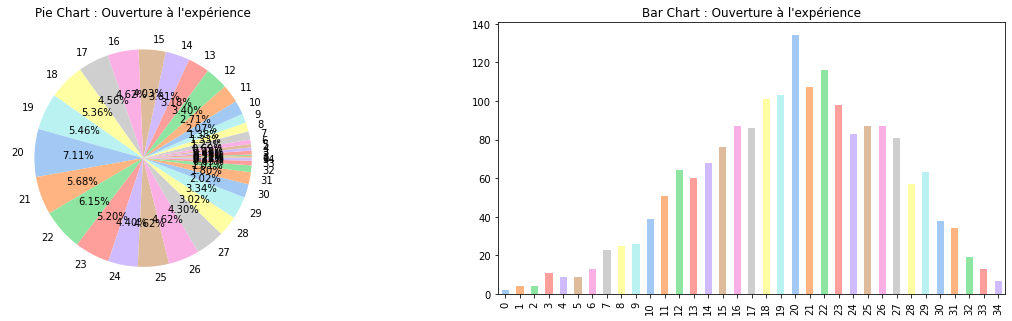

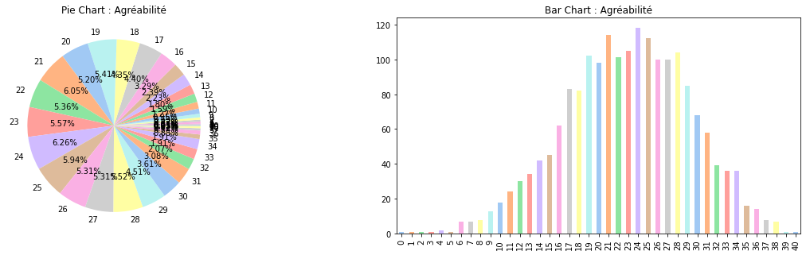

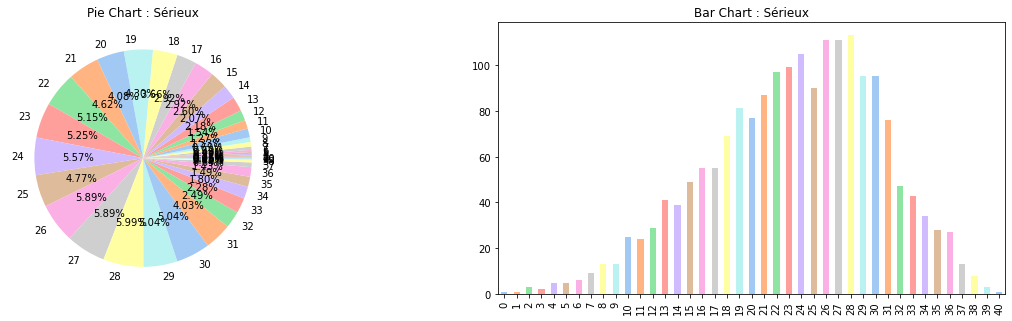

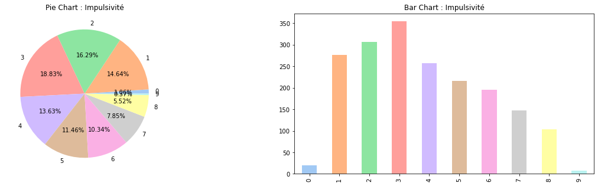

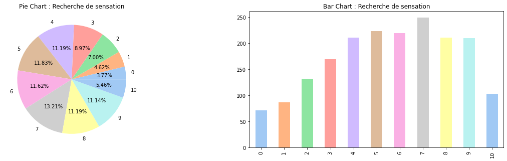

```python
visu(df, 'Neuroticisme')
visu(df, 'Extraversion')
visu(df, 'Ouverture à l\'expérience')
visu(df, 'Agréabilité')
visu(df, 'Sérieux')
visu(df, 'Impulsivité')
visu(df, 'Recherche de sensation')
```

Ces graphes sont difficiles à interpréter car il y a plusieurs niveaux pour ces traits de personnalité. On remarque toutefois grâce aux pie charts qu' il ne semble pas y avoir de déséquilibre important.

#### Corrélation entre les différents traits de personnalité

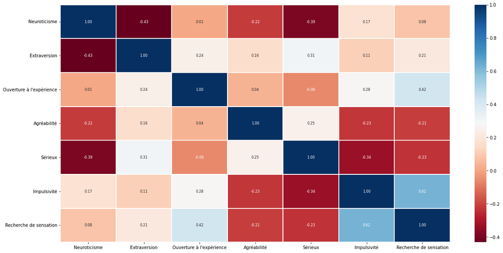

```python
corr = data[col_personnalité].corr()
plt.figure(figsize=(20,10))
sns.heatmap(corr, cmap='RdBu',annot=True, annot_kws={"fontsize":8}, linewidth = 0.1, fmt='.2f')
```

Aucune corrélation forte, mais quelques corrélations modérées. Le signe de la corrélation peut être intéressant à prendre en compte.

Le neuroticisme, par exemple, a peu de corrélations positives avec les autres traits de personnalité. Il présente une corrélation descendante faible-modérée avec l'extraversion et le sérieux.

#### Visualisation du nombre de consommateurs par classe et par drogue

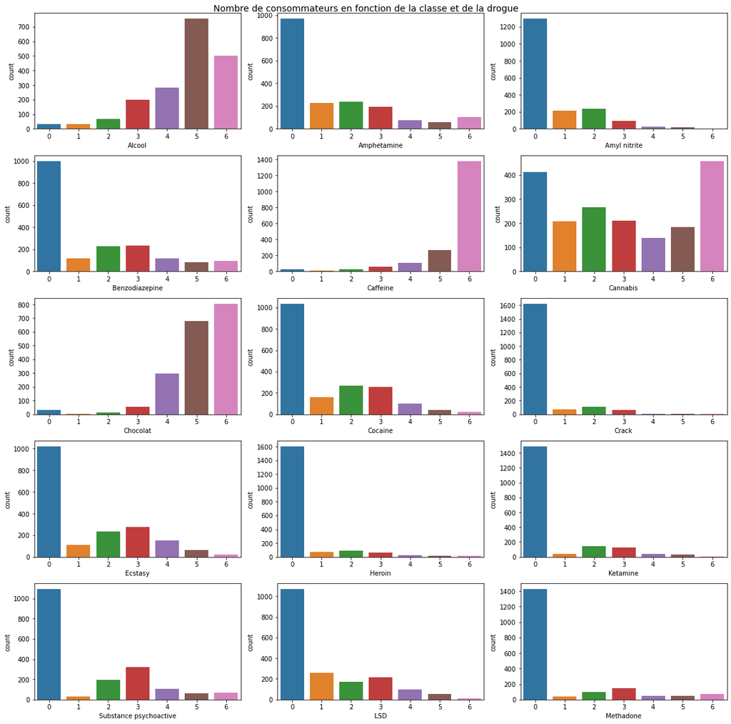

```python
fig, axes = plt.subplots(5,3,figsize = (16,16))
fig.suptitle("Nombre de consommateurs en fonction de la classe et de la drogue",fontsize=14)
k=0
for i in range(5):
    for j in range(3):
        sns.countplot(x=col_drogue[k], data=data,ax=axes[i][j])
        k+=1

plt.tight_layout()
plt.show()
```

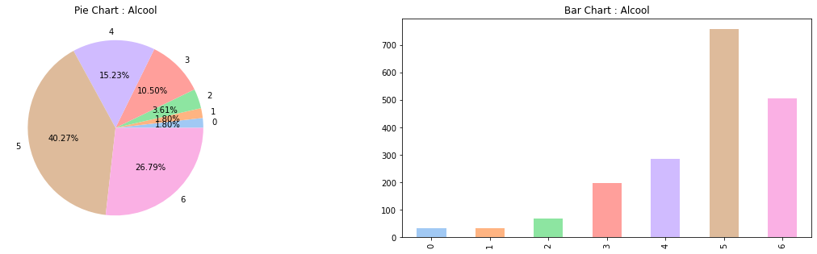

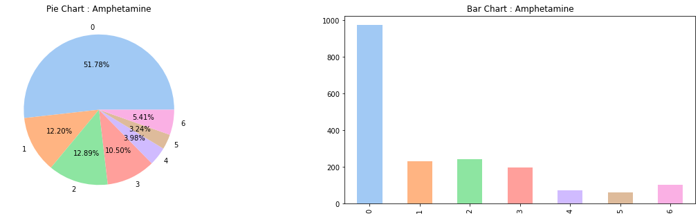

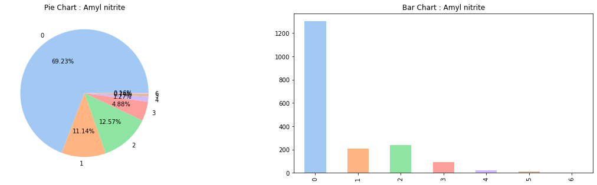

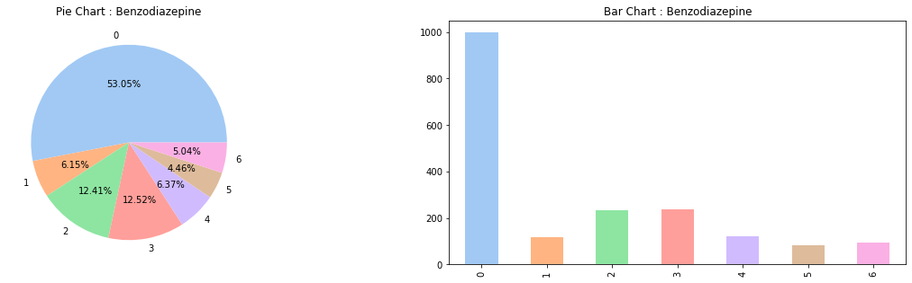

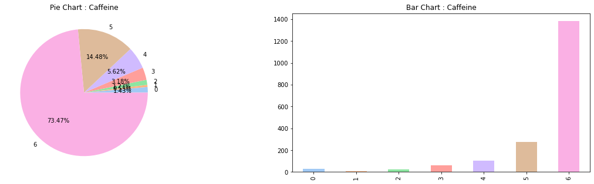

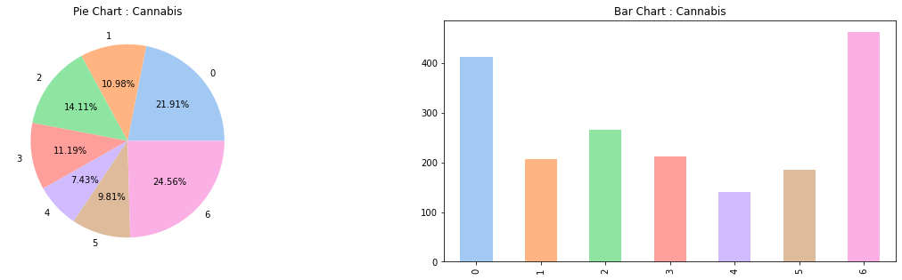

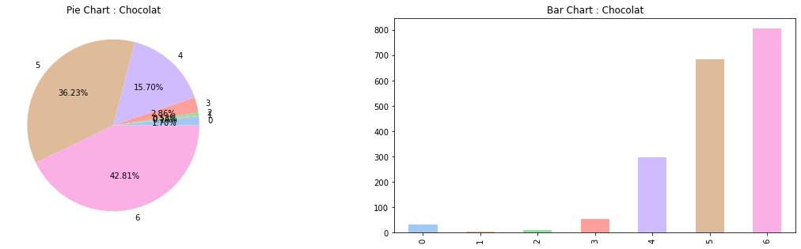

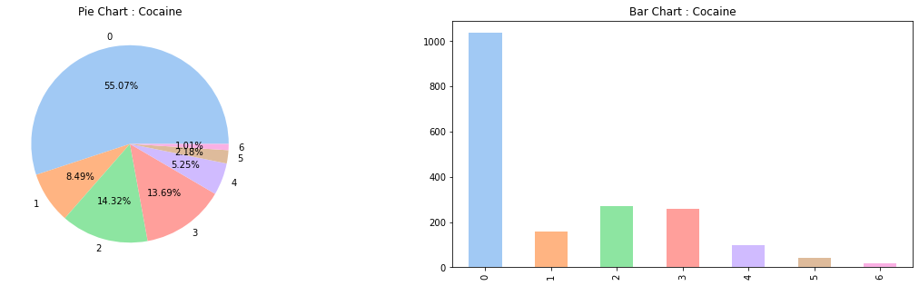

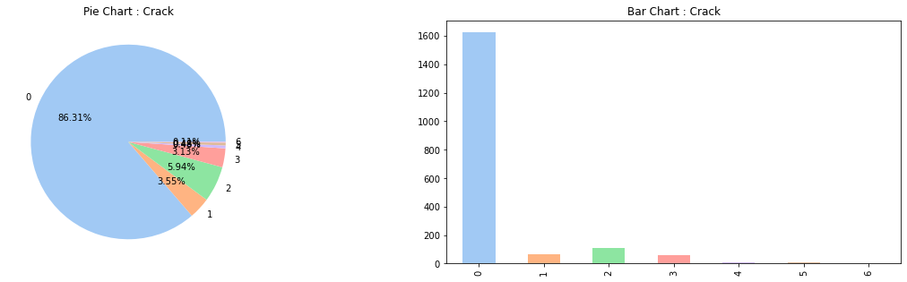

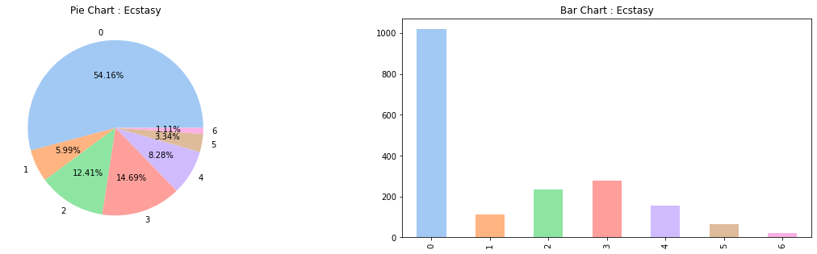

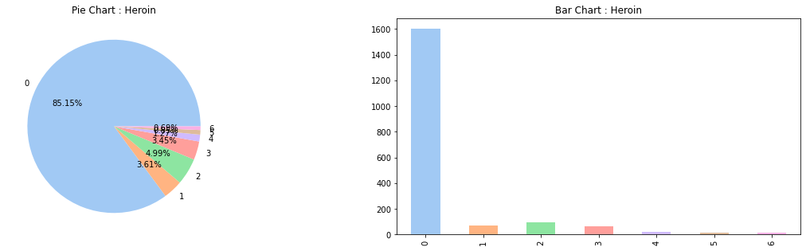

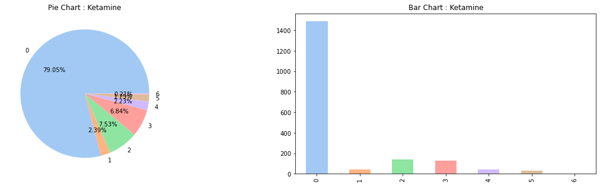

[6 more figures not shown]

```python
visu(df, 'Alcool')
visu(df, 'Amphetamine')
visu(df, 'Amyl nitrite')
visu(df, 'Benzodiazepine')
visu(df, 'Caffeine')
visu(df, 'Cannabis')
visu(df, 'Chocolat')
visu(df, 'Cocaine')
visu(df, 'Crack')
visu(df, 'Ecstasy')
visu(df, 'Heroin')
visu(df, 'Ketamine')
visu(df, 'Substance psychoactive')
visu(df, 'LSD')
visu(df, 'Methadone')
visu(df, 'Champignon hallucinogène')
visu(df, 'Nicotine')
visu(df, 'Substance Volatile')
```

```python
count_regusers = []
count_nonregusers = []
for i in range(len(col_drogue)):
    s = data_regulier.groupby([col_drogue[i]])[col_drogue[i]].count()
    count_regusers.append(s[1])
    count_nonregusers.append(s[0])

trace1 = go.Bar(
    x=col_drogue,
    y=count_regusers,
    name='Regular User',
    marker = dict(color="mediumslateblue")
)
trace2 = go.Bar(
    x=col_drogue,
    y=count_nonregusers,
    name='Non Regular User',
    marker = dict(color="lightcoral")
)


datafig = [trace1, trace2]
layout = go.Layout(
    title= 'Count of Regular User Or Non Regular User for each drug',
    yaxis=dict(title='Count', ticklen=5, gridwidth=2),
    barmode='group'
)

fig = go.Figure(data=datafig, layout=layout)
py.iplot(fig, filename='grouped-bar')
```

[interactive chart not shown]

Nous avons pu voir que certaines drogues n'ont jamais été consommées par la majorité des participants (plus de 50%), tandis que d'autres, comme l'alcool, la nicotine ou le cannabis, sont beaucoup plus consommées (régulièrement ou non), et d'autres 'drogues' comme la caféine ou le chocolat sont consommées par presque tous les participants très régulièrement.

#### Corrélation entre les drogues

On remarque quelques corrélations modérées entre certaines drogues sur la heatmap ci-dessous.

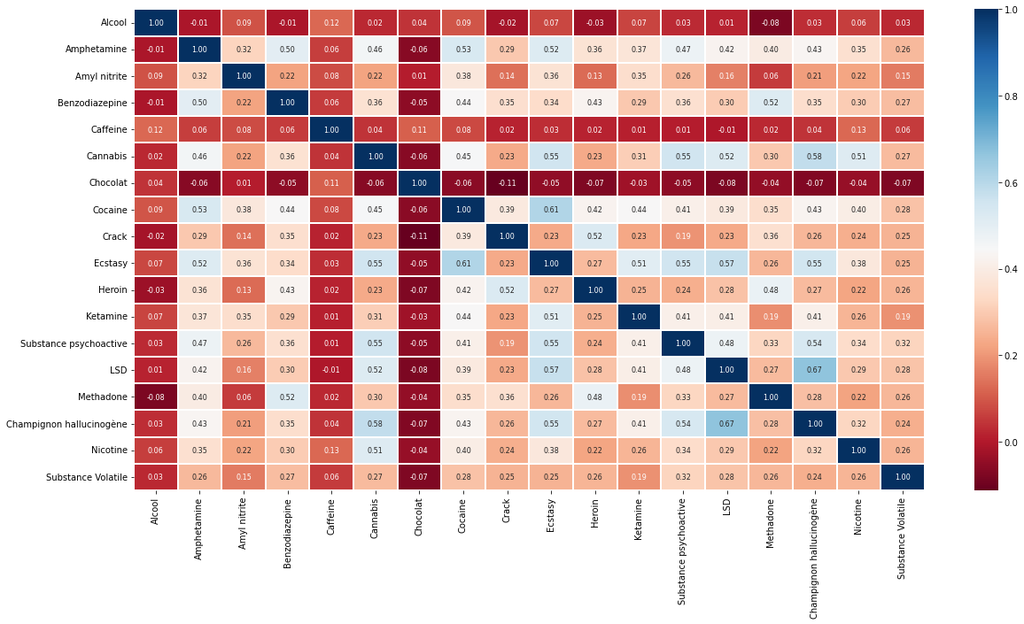

```python
corr = data[col_drogue].corr()
plt.figure(figsize=(20,10))
sns.heatmap(corr, cmap='RdBu',annot=True, annot_kws={"fontsize":8}, linewidth = 0.1, fmt='.2f')
```

#### Corrélations entre les drogues et les caractéristiques démographiques et de personnalité

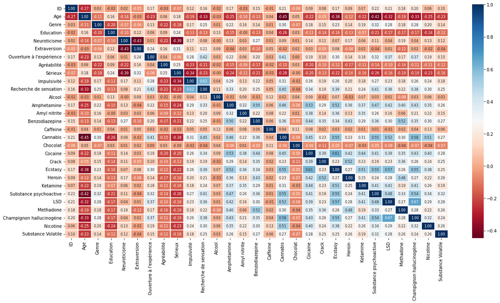

```python
corr = data.corr()
plt.figure(figsize=(20,10))
sns.heatmap(corr, cmap='RdBu',annot=True, annot_kws={"fontsize":8}, linewidth = 0.1, fmt='.2f')
```

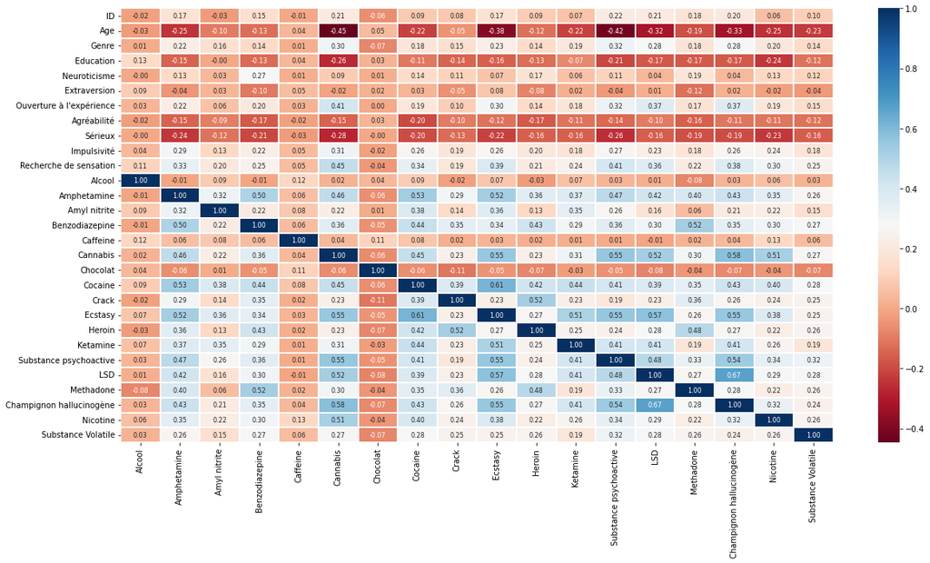

```python
corr = data.corr()[col_drogue]
plt.figure(figsize=(20,10))
sns.heatmap(corr, cmap='RdBu',annot=True, annot_kws={"fontsize":8}, linewidth = 0.1, fmt='.2f')
```

Les valeurs intéressantes sont les corrélations entre la consommation de drogues et les autres caractéristiques (de démographie et de personnalité).

Les caractéristiques démographiques semblent avoir de nombreuses corrélations négatives ou très proches de 0, tandis que certains traits de personnalité semblent avoir des corrélations positives, comme "l'ouverture à l'expérience", "l'impulsivité" ou "la recherche de sensations".

On observe aussi que les corrélations les plus fortes sont entre 2 drogues entre elles : par exemple, la corrélation entre la Cocaïne et l'Ecstasy est de 0,61, et celle entre les champignons hallucinogènes et le LSD est de 0,67.

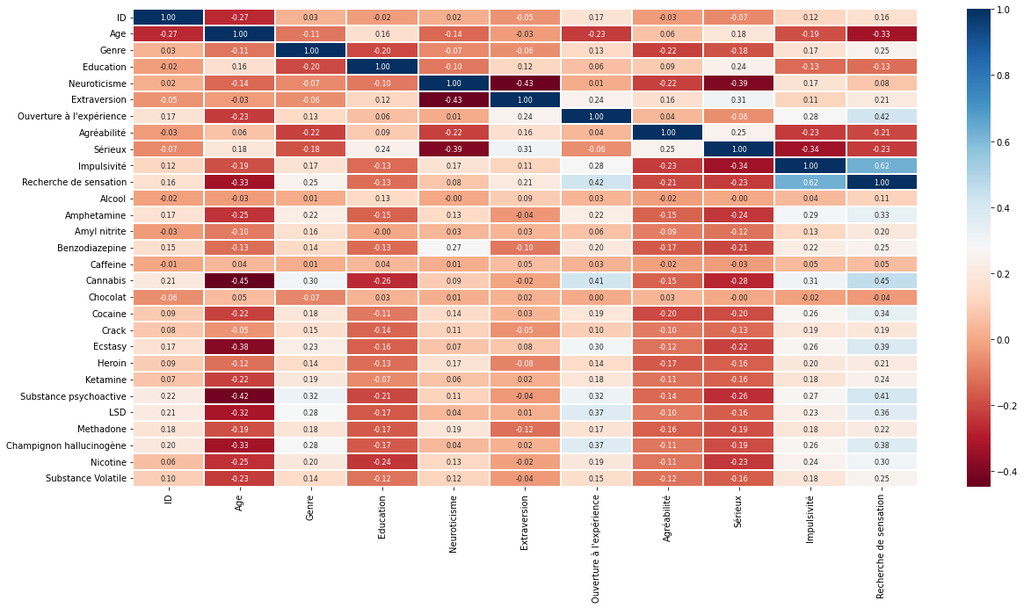

```python
corr = data.corr()[col_démographie+col_personnalité]
plt.figure(figsize=(20,10))
sns.heatmap(corr, cmap='RdBu',annot=True, annot_kws={"fontsize":8}, linewidth = 0.1, fmt='.2f')
```